# Force Edge Experiment - TP

Sami BARCHID

# 1. Introduction

On effectue l’analyse statistique de la première expérience étudiée dans l’article de recherche [ForceEdge: Controlling Autoscroll on Both Desktop and Mobile Computers Using the Force](https://hal.inria.fr/hal-01444366/document). On définit ici les constatations que l’on peut faire sur le travail qu’on est amené à faire sur l’expérience.

## 1.1. Caractéristiques de l’expérience

Les variables dépendantes principale de l’expérience (càd celles qui sont importantes pour répondre aux hypothèses émises) sont : - **time** : temps mis par le participant pour réaliser la tâche. - **overshoot** : la distance d’overshoot = la distance de dépassement enregistrée.

## 1.2. Test statistique à utiliser

A partir de ces deux constatations, on définit que le test statistique à utiliser est le **Repeated measures ANOVA**.

# 2. Réplication des analyses statistiques de l’article ForceEdge

## 2.1. Chargement des données

Lecture des données du fichier `ForceEdgeStudy1.csv`.

```r
data = read.table("ForceEdgeStudy1.csv", header=TRUE, sep=",")
#kable(data)
```

## 2.2. Filtrage et agrégation des données

Conversion des données en format long pour que l’utilisation d’ANOVA fonctionne. C’est une contrainte qu’on ne sait pas pourquoi elle est là en bref…

```r
data.long = melt(data, id = c("participant","task", "technique", "block", "distance", "repetition", "trial", "time", "overshoot", "success"))
```

#### 2.2.3. Conserver uniquement les essais réussis

On opère un filtre sur les données pour ne conserver que les essais qui ont eu un `success = true` (donc qui ont réussi).

```r
successful = data.long %>% filter(success == "True")
```

#### 2.2.4. Regroupement et calcul d’agrégations

On recherche maintenant à organiser les données par task, technique et distance et de calculer, pour chaque sous-groupe, le temps moyen ainsi que les bornes inférieures et supérieures des intervalles de confiance à 95%.

Ces bornes inférieures et supérieures des intervalles de confiance à 95% permettent de vérifier que les niveaux d’une variable indépendante influencent les résultats mesurés sur une variable dépendante ou si, au contraire, ça ne change rien.

```r
grouped = successful %>%  group_by(task, technique, distance) %>% summarise(meanTime = mean(time), ci.lower = ci(time)["CI lower"], ci.upper = ci(time)["CI upper"])
```

[output not shown]

```r
kable(grouped)
```

| task | technique | distance | meanTime | ci.lower | ci.upper |
| --- | --- | --- | --- | --- | --- |
| Move | Baseline | 15 | 3.443701 | 3.277448 | 3.609954 |
| Move | Baseline | 135 | 9.936179 | 9.553152 | 10.319206 |
| Move | Baseline | 250 | 13.767817 | 13.176497 | 14.359136 |
| Move | ForceEdge | 15 | 3.085130 | 2.865215 | 3.305045 |
| Move | ForceEdge | 135 | 5.697924 | 5.347685 | 6.048163 |
| Move | ForceEdge | 250 | 5.918678 | 5.560975 | 6.276382 |
| Select | Baseline | 15 | 2.551179 | 2.421636 | 2.680721 |
| Select | Baseline | 135 | 5.569686 | 5.293451 | 5.845921 |
| Select | Baseline | 250 | 6.130750 | 5.786540 | 6.474960 |
| Select | ForceEdge | 15 | 2.596671 | 2.437427 | 2.755914 |
| Select | ForceEdge | 135 | 5.315769 | 5.028766 | 5.602771 |
| Select | ForceEdge | 250 | 5.465907 | 5.164036 | 5.767777 |

## 2.3. Visualisation

On veut maintenant montrer si le temps moyen d’un essai suivant la technique et la distance utilisée. Pour ce faire, on reproduit la figure 4 à gauche de l’article original. - Le premier graphique montre le temps moyen d’un essai suivant la technique et la distance utilisée pour les tâches de “Move”. - Le deuxième graphique montre le temps moyen d’un essai suivant la technique et la distance utilisée pour les tâches de “Select”.

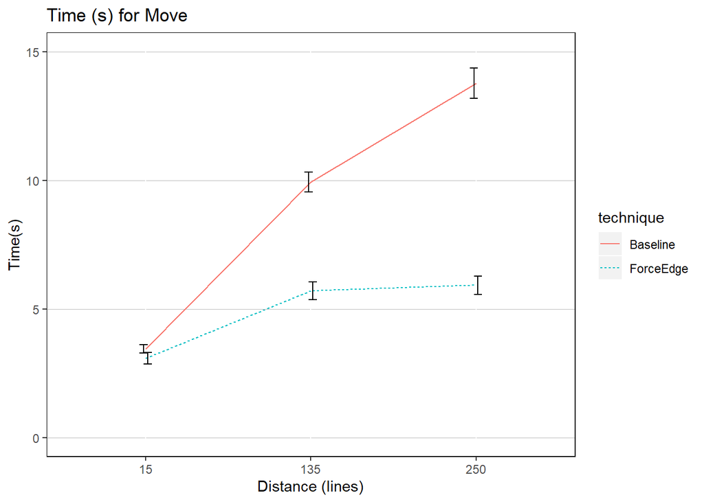

```r
# Plot pour la tâche de "Move"
grouped_move = grouped %>% filter(task == "Move")
ggplot(grouped_move, aes(x = factor(distance), y = meanTime, group=technique)) +
      geom_line(aes(colour=technique, linetype=technique)) +
      ylim(0, 15) +
      geom_errorbar(aes(ymin = ci.lower, ymax = ci.upper), width = .1, position = position_dodge(.05)) +
      theme(panel.background = element_blank(),
            panel.border = element_rect(colour = 'black', fill=NA),
            panel.grid.major.y = element_line( size = .1, color = "grey")
      ) +
      labs(title = "Time (s) for Move", x = "Distance (lines)", y = "Time(s)")
```

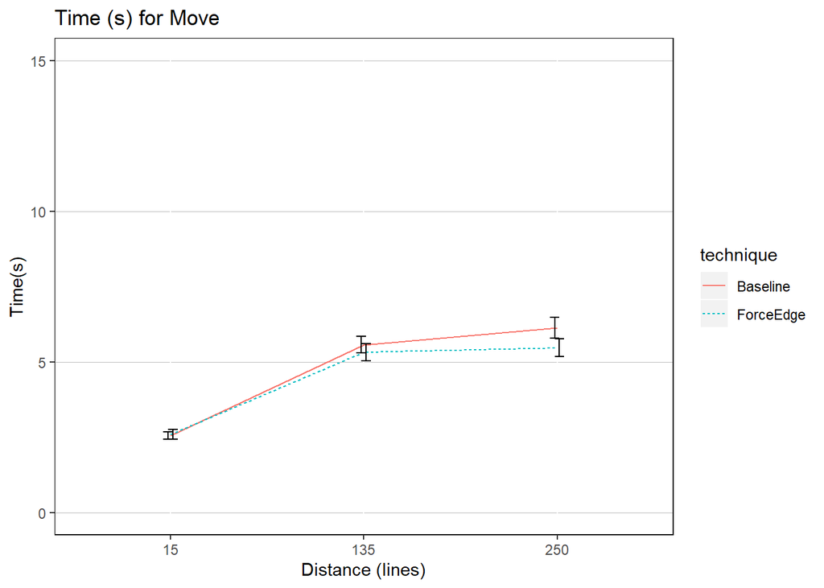

```r
# Plot pour la tâche de "Select"
grouped_select = grouped %>% filter(task == "Select")
ggplot(grouped_select, aes(x = factor(distance), y = meanTime, group=technique)) +
      geom_line(aes(colour=technique, linetype=technique)) +
      ylim(0, 15) +
      geom_errorbar(aes(ymin = ci.lower, ymax = ci.upper), width = .1, position = position_dodge(.05)) +
      theme(panel.background = element_blank(),
            panel.border = element_rect(colour = 'black', fill=NA),
            panel.grid.major.y = element_line( size = .1, color = "grey")
      ) +
      labs(title = "Time (s) for Move", x = "Distance (lines)", y = "Time(s)")
```

Avec ces deux graphiques, nous observons ici plusieurs choses :

- Dans les deux tâches (Move et Select), le temps enregistré ne montre pas de différence significative entre les deux techniques lorsque la distance utilisée est la plus courte.
- Pour la tâche de Select, on n’observe pas de différence significative entre les deux techniques (Force Edge et Baseline).
- Dans les autres cas de figure, on observe une différence significative entre les deux techniques.

## 2.4. ANOVA sur le temps

Dans ce chapitre, on cherche à utiliser la repeated measure ANOVA afin de constater les différences significatives entre les paramètres.

#### 2.4.1. Constater l’effet d’apprentissage

L’objectif ici est de constater l’effet d’apprentissage observé en montrant la différence significative entre le bloc 1 et les autres. Pour ce faire, on réalise une Repeated Measure ANOVA sur les blocs et sur les autres variables indépendantes.

```r
# Préparation pour l'ANOVA
successful$technique = factor(successful$technique)
successful$task = factor(successful$task)
successful$distance = factor(successful$distance)
successful$block = factor(successful$block)

# Lancement de l'ANOVA
anova_result = ezANOVA(successful, dv=.(time), wid=.(participant), within=.(technique, task, block, distance))
kable(anova_result$ANOVA)
```

|  | Effect | DFn | DFd | F | p | p<.05 | ges |
| --- | --- | --- | --- | --- | --- | --- | --- |
| 2 | technique | 1 | 15 | 119.2730365 | 0.0000000 | * | 0.2697542 |
| 3 | task | 1 | 15 | 98.9358119 | 0.0000001 | * | 0.2962823 |
| 4 | block | 2 | 30 | 62.0877462 | 0.0000000 | * | 0.0991421 |
| 5 | distance | 2 | 30 | 146.7917064 | 0.0000000 | * | 0.5664354 |
| 6 | technique:task | 1 | 15 | 72.7945408 | 0.0000004 | * | 0.2180628 |
| 7 | technique:block | 2 | 30 | 0.8289316 | 0.4462671 |  | 0.0025199 |
| 8 | task:block | 2 | 30 | 19.7622053 | 0.0000033 | * | 0.0214166 |
| 9 | technique:distance | 2 | 30 | 117.3509944 | 0.0000000 | * | 0.1736162 |
| 10 | task:distance | 2 | 30 | 62.4179882 | 0.0000000 | * | 0.1232550 |
| 11 | block:distance | 4 | 60 | 6.4847655 | 0.0002095 | * | 0.0149169 |
| 12 | technique:task:block | 2 | 30 | 5.4323453 | 0.0096961 | * | 0.0127332 |
| 13 | technique:task:distance | 2 | 30 | 44.7274784 | 0.0000000 | * | 0.1256750 |
| 14 | technique:block:distance | 4 | 60 | 3.6808999 | 0.0095578 | * | 0.0073369 |
| 15 | task:block:distance | 4 | 60 | 5.2850392 | 0.0010298 | * | 0.0086300 |
| 16 | technique:task:block:distance | 4 | 60 | 4.9977450 | 0.0015226 | * | 0.0120687 |

```r
#print(anova_result$ANOVA)
```

L’ANOVA révèle un effet d’apprentissage au vu de l’impact significatif sur le temps passé à faire la tâche ($F_{2,30} = 62.09$, $p < 0.05$). On veut maintenant identifier le block qui entraîne cet impact significatif. Pour ce faire, on exécute un post-hoc test :

```r
attach(successful)
pw <- pairwise.t.test(time, factor(block), paired=T, p.adj = "bonferroni")
detach(successful)
print(pw$p.value)
```

```
##              1            2
## 2 3.840816e-30           NA
## 3 2.380138e-45 0.0005333282
```

On observe ici un effet d’apprentissage entre le bloc 1 et les deux autres blocs.

#### 2.4.2. Analyse des autres variables indépendantes

Pour éviter le biais dû à l’effet d’apprentissage, on supprime les données du premier bloc dans le but de relancer l’ANOVA et de voir les impacts significatifs pour les autres variables indépendantes.

```r
# Filtrage du block 1
without_block1 = successful %>% filter(block != 1)
anova_result = ezANOVA(without_block1, dv=.(time), wid=.(participant), within=.(technique, task, block, distance))
kable(anova_result$ANOVA)
```

|  | Effect | DFn | DFd | F | p | p<.05 | ges |
| --- | --- | --- | --- | --- | --- | --- | --- |
| 2 | technique | 1 | 15 | 121.6254498 | 0.0000000 | * | 0.2594429 |
| 3 | task | 1 | 15 | 61.4451682 | 0.0000011 | * | 0.2407513 |
| 4 | block | 1 | 15 | 5.6081276 | 0.0317373 | * | 0.0059856 |
| 5 | distance | 2 | 30 | 108.6155608 | 0.0000000 | * | 0.5461080 |
| 6 | technique:task | 1 | 15 | 42.7232409 | 0.0000094 | * | 0.1764966 |
| 7 | technique:block | 1 | 15 | 0.0613439 | 0.8077426 |  | 0.0000624 |
| 8 | task:block | 1 | 15 | 0.5528522 | 0.4686419 |  | 0.0002823 |
| 9 | technique:distance | 2 | 30 | 78.2064480 | 0.0000000 | * | 0.1516463 |
| 10 | task:distance | 2 | 30 | 34.2521855 | 0.0000000 | * | 0.0936046 |
| 11 | block:distance | 2 | 30 | 1.7502120 | 0.1910136 |  | 0.0020461 |
| 12 | technique:task:block | 1 | 15 | 0.0036154 | 0.9528475 |  | 0.0000088 |
| 13 | technique:task:distance | 2 | 30 | 19.8456169 | 0.0000032 | * | 0.0885088 |
| 14 | technique:block:distance | 2 | 30 | 2.9054399 | 0.0702415 |  | 0.0024021 |
| 15 | task:block:distance | 2 | 30 | 0.7272200 | 0.4915746 |  | 0.0007331 |
| 16 | technique:task:block:distance | 2 | 30 | 0.0623549 | 0.9396709 |  | 0.0001141 |

## 2.5. ANOVA sur les questionnaires NASA-TLX

Dans cette partie, nous cherchons à refaire l’analyse de Friedman sur les rapports NASA-TLX remplis par les participants après chaque techniques. Le but est de refaire l’analyse de Friedman sur l’item “frustration”.

#### 2.5.1. Organisation des données

On charge les données et on les réorganise pour mesurer l’item “frustration”.

```r
# Chargement de données
nasa = read.table("ForceEdgeStudy1NasaTLX.csv", header=TRUE, sep=",")

# Trier pour n'avoir que les item frustration
nasa = nasa %>% filter(question == "frustration")
nasa$question = NULL

# Regrouper les données de participants par participant pour chaque couple (task,technique)
#   NOTE: c'est dégueulasse, mais ça fonctionne.....
nasa_formatted = nasa %>% group_by(participant) %>% summarise(
  ForceEdge_Select = sum(score[technique == "ForceEdge" & task == "Select"]),
  Baseline_Select = sum(score[technique == "Baseline" & task == "Select"]),
  ForceEdge_Move = sum(score[technique == "ForceEdge" & task == "Move"]),
  Baseline_Move = sum(score[technique == "Baseline" & task == "Move"]),
)
```

- On peut maintenant afficher les données formatées pour lancer le test.

```r
kable(nasa_formatted)
```

| participant | ForceEdge_Select | Baseline_Select | ForceEdge_Move | Baseline_Move |
| --- | --- | --- | --- | --- |
| 0 | 5 | 13 | 4 | 20 |
| 1 | 4 | 11 | 6 | 9 |
| 2 | 2 | 2 | 1 | 17 |
| 3 | 3 | 2 | 3 | 13 |
| 4 | 11 | 6 | 8 | 20 |
| 5 | 9 | 12 | 12 | 20 |
| 6 | 8 | 19 | 3 | 17 |
| 7 | 12 | 15 | 15 | 17 |
| 8 | 14 | 17 | 4 | 19 |
| 9 | 13 | 7 | 7 | 18 |
| 10 | 2 | 2 | 6 | 15 |
| 11 | 8 | 8 | 5 | 11 |
| 12 | 11 | 5 | 7 | 7 |
| 13 | 4 | 5 | 5 | 5 |
| 14 | 1 | 10 | 1 | 17 |
| 15 | 7 | 8 | 9 | 14 |

#### 2.5.2. Test

On lance ici le test de Friedman.

```r
nasa_formatted$participant = NULL
pander(friedman.test(data.matrix(nasa_formatted)))
```

Friedman rank sum test: `data.matrix(nasa_formatted)`

| Test statistic | df | P value |
| --- | --- | --- |
| 21.94 | 3 | 6.717e-05 * * * |

On observe un impact significatif du couple (task,technique) dans la mesure de la frustration. On peut donc conclure que, pour une tâche et une technique donnée, les utilisateurs peuvent trouver l’exécution plus ou moins frustrante.